# Changes in peatland soil fauna biomass alter food web structure and function under warming and hydrological changes

## 3.7 Soil Food Web Carbon and Nitrogen Flux

### Figure 3.7

Modeled rates of (A) carbon flux (consumption), (B) carbon mineralization (respiration), and (C) nitrogen mineralization.

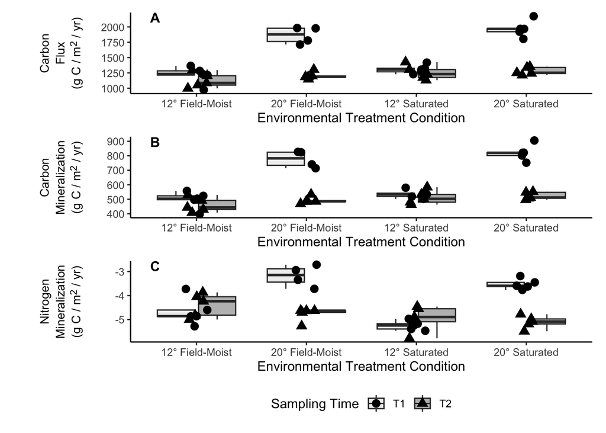

```r
flux_data_T1uT2 <- flux_data %>%
  filter(!destructive_time == "T0") %>%
  filter(!Sample_ID == "ExRes 5")

flux_data_T1uT2$tx <- interaction(flux_data_T1uT2$temp_tx,
                                  flux_data_T1uT2$moisture_tx)

flux_data_T1uT2 <- flux_data_T1uT2 %>%
  mutate(tx = fct_recode(tx,
    "12\u00B0 Field-Moist" = "12.Ambient",
    "20\u00B0 Field-Moist" = "20.Ambient",
    "12\u00B0 Saturated"   = "12.High",
    "20\u00B0 Saturated"   = "20.High"
  ))

ylab_consumption <-
  "<span style='font-size:10pt'>Carbon<br>Flux<br>(g C / m<sup>2</sup> / yr)</span>"
ylab_Cmin  <-
  "<span style='font-size:10pt'>Carbon Mineralization (g C / m<sup>2</sup> / yr)</span>"
ylab_Nmin  <- "
<span style='font-size:10pt'>Nitrogen Mineralization (g C / m<sup>2</sup> / yr)</span>"

consumption_plot <-
  ggplot(flux_data_T1uT2, aes(x=tx, y=total_consumption,
                            fill = as.factor(destructive_time))) +
  geom_boxplot(outlier.shape=NA) + #avoid plotting outliers twice
  geom_jitter(aes(pch = as.factor(destructive_time)),
              position=position_jitter(width=.1, height=0), size = 3) +
  theme(panel.grid.major = element_blank(),
        panel.grid.minor = element_blank(),
        panel.background = element_blank(),
        axis.line = element_line(colour = "black"),
        axis.title.y = element_textbox_simple(orientation="left-rotated",
                                              halign = 0.5,
                                              margin = margin(b = 15))) +
  scale_fill_brewer(palette = "Greys") +
  xlab("Environmental Treatment Condition") +
  ylab(ylab_consumption) +
  labs(fill = "Sampling Time", pch = "Sampling Time")

Cmin_plot <-
  ggplot(flux_data_T1uT2, aes(x=tx, y=total_Cmin,
                            fill = as.factor(destructive_time))) +
  geom_boxplot(outlier.shape=NA) + #avoid plotting outliers twice
  geom_jitter(aes(pch = as.factor(destructive_time)),
              position=position_jitter(width=.1, height=0), size = 3) +
  theme(panel.grid.major = element_blank(),
        panel.grid.minor = element_blank(),
        panel.background = element_blank(),
        axis.line = element_line(colour = "black"),
        axis.title.y = element_textbox_simple(orientation="left-rotated",
                                              halign = 0.5,
                                              margin = margin(b = 15))) +
  scale_fill_brewer(palette = "Greys") +
  xlab("Environmental Treatment Condition") +
  ylab(ylab_Cmin) +
  labs(fill = "Sampling Time", pch = "Sampling Time")

Nmin_plot <-
  ggplot(flux_data_T1uT2, aes(x=tx, y=total_Nmin,
                            fill = as.factor(destructive_time))) +
  geom_boxplot(outlier.shape=NA) + #avoid plotting outliers twice
  geom_jitter(aes(pch = as.factor(destructive_time)),
              position=position_jitter(width=.1, height=0), size = 3) +
  theme(panel.grid.major = element_blank(),
        panel.grid.minor = element_blank(),
        panel.background = element_blank(),
        axis.line = element_line(colour = "black"),
        axis.title.y = element_textbox_simple(orientation="left-rotated",
                                              halign = 0.5,
                                              margin = margin(b = 15))) +
  scale_fill_brewer(palette = "Greys") +
  xlab("Environmental Treatment Condition") +
  ylab(ylab_Nmin) +
  labs(fill = "Sampling Time", pch = "Sampling Time")

f1 <- place_tag(consumption_plot, "A", x_left = 0.58)
f2 <- place_tag(Cmin_plot,            "B", x_left = 0.58)
f3 <- place_tag(Nmin_plot,            "C", x_left = 0.58)

(f1 / f2 / f3) +
  plot_layout(ncol = 1, guides = "collect") &
  theme(legend.position = "bottom")
```

```r
consumption_lm <- lm(total_consumption ~
                          moisture_tx * temp_tx * destructive_time +
                          moisture_tx * temp_tx +
                          moisture_tx * destructive_time +
                          temp_tx * destructive_time +
                          moisture_tx +
                          temp_tx +
                          destructive_time +
                          block_effect,
                     data = flux_data_T1uT2)

consumption_lm2 <- lm(total_consumption ~



                        temp_tx * destructive_time +
                        moisture_tx +
                        temp_tx +
                        destructive_time +
                        block_effect,
                data = flux_data_T1uT2)

Cmin_lm <- lm(total_Cmin ~
                          moisture_tx * temp_tx * destructive_time +
                          moisture_tx * temp_tx +
                          moisture_tx * destructive_time +
                          temp_tx * destructive_time +
                          moisture_tx +
                          temp_tx +
                          destructive_time +
                          block_effect,
                     data = flux_data_T1uT2)

Cmin_lm2 <- lm(total_Cmin ~



                temp_tx * destructive_time +
                moisture_tx +
                temp_tx +
                destructive_time +
                block_effect,
                data = flux_data_T1uT2)

Nmin_lm <- lm(total_Nmin ~
                        moisture_tx * temp_tx * destructive_time +
                        moisture_tx * temp_tx +
                        moisture_tx * destructive_time +
                        temp_tx * destructive_time +
                        moisture_tx +
                        temp_tx +
                        destructive_time +
                        block_effect,
                    data = flux_data_T1uT2)

Nmin_lm2 <- lm(total_Nmin ~



                temp_tx * destructive_time +
                moisture_tx +
                temp_tx +
                destructive_time +
                block_effect,
               data = flux_data_T1uT2)
```

Mean total consumptive flux, C mineralization, and N mineralization were compared across 39 mesocosms. Mean total consumptive flux (W = 0.988, p = 0.944), C mineralization (W = 0.987, p = 0.933), and N mineralization (W = 0.981, p = 0.751) met the assumption of normality, per a Shapiro-Wilk test. Mean total consumptive flux (F₇ˌ₃₁ = 0.719, p = 0.657), C mineralization (F₇ˌ₃₁ = 0.747, p = 0.635), and N mineralization (F₇ˌ₃₁ = 0.847, p = 0.558) also met the assumption of homogeneity of variance, per Levene’s test.

### Supplemental Table 3.N

Shapiro-Wilk and Levene’s Tests constructed to test whether total consumptive flux, C mineralization, and N mineralization conform to the assumptions of normality and homodescacity.

```r
flux_df1 <- as.data.frame(matrix(data = c(
  "Total Consumptive Flux",
  "Shapiro-Wilk Test",
  paste0("W = ",
         format(round(shapiro_test(residuals(consumption_lm2))$statistic, 3),
         nsmall = 3)),
  paste0("p = ",
         format(round(shapiro_test(residuals(consumption_lm2))$p.value, 3),
         nsmasll = 3)),
  "Total Consumptive Flux",
  "Levene's Test",
  paste0("F", sub_digits(
    levene_test(total_consumption ~ (moisture_tx * temp_tx * destructive_time),
              data = flux_data_T1uT2)$df1), "\u02CC",
  sub_digits(
    levene_test(total_consumption ~ (moisture_tx * temp_tx * destructive_time),
              data = flux_data_T1uT2)$df2), " = ",
  format(round(levene_test(total_consumption ~
                             (moisture_tx * temp_tx * destructive_time),
              data = flux_data_T1uT2)$statistic, 3), nsmall = 3)),
  paste0("p = ", format(round(levene_test(total_consumption ~
                             (moisture_tx * temp_tx * destructive_time),
              data = flux_data_T1uT2)$p, 3), nsmall = 3)),
  "Carbon Minderalization",
  "Shapiro-Wilk Test",
  paste0("W = ",
         format(round(shapiro_test(residuals(Cmin_lm2))$statistic, 3),
         nsmall = 3)),
  paste0("p = ",
         format(round(shapiro_test(residuals(Cmin_lm2))$p.value, 3),
         nsmasll = 3)),
  "Carbon Minderalization",
  "Levene's Test",
  paste0("F", sub_digits(
    levene_test(total_Cmin ~ (moisture_tx * temp_tx * destructive_time),
              data = flux_data_T1uT2)$df1), "\u02CC",
  sub_digits(
    levene_test(total_Cmin ~ (moisture_tx * temp_tx * destructive_time),
              data = flux_data_T1uT2)$df2), " = ",
  format(round(levene_test(total_Cmin ~
                             (moisture_tx * temp_tx * destructive_time),
              data = flux_data_T1uT2)$statistic, 3), nsmall = 3)),
  paste0("p = ", format(round(levene_test(total_Cmin ~
                             (moisture_tx * temp_tx * destructive_time),
              data = flux_data_T1uT2)$p, 3), nsmall = 3)),
  "Nitrogen Minderalization",
  "Shapiro-Wilk Test",
  paste0("W = ",
         format(round(shapiro_test(residuals(Nmin_lm2))$statistic, 3),
         nsmall = 3)),
  paste0("p = ",
         format(round(shapiro_test(residuals(Nmin_lm2))$p.value, 3),
         nsmasll = 3)),
  "Nitrogen Minderalization",
  "Levene's Test",
  paste0("F", sub_digits(
    levene_test(total_Nmin ~ (moisture_tx * temp_tx * destructive_time),
              data = flux_data_T1uT2)$df1), "\u02CC",
  sub_digits(
    levene_test(total_Nmin ~ (moisture_tx * temp_tx * destructive_time),
              data = flux_data_T1uT2)$df2), " = ",
  format(round(levene_test(total_Nmin ~
                             (moisture_tx * temp_tx * destructive_time),
              data = flux_data_T1uT2)$statistic, 3), nsmall = 3)),
  paste0("p = ", format(round(levene_test(total_Nmin ~
                             (moisture_tx * temp_tx * destructive_time),
              data = flux_data_T1uT2)$p, 3), nsmall = 3))
  ), ncol = 4, byrow = T))

colnames(flux_df1) <-
  c("Parameter", "Test", "Statistic", "P-Value")

knitr::kable(flux_df1, linesep = "\\hline")
```

| Parameter | Test | Statistic | P-Value |
| --- | --- | --- | --- |
| Total Consumptive Flux | Shapiro-Wilk Test | W = 0.988 | p = 0.944 |
| Total Consumptive Flux | Levene’s Test | F₇ˌ₃₁ = 0.719 | p = 0.657 |
| Carbon Minderalization | Shapiro-Wilk Test | W = 0.987 | p = 0.933 |
| Carbon Minderalization | Levene’s Test | F₇ˌ₃₁ = 0.747 | p = 0.635 |
| Nitrogen Minderalization | Shapiro-Wilk Test | W = 0.981 | p = 0.751 |
| Nitrogen Minderalization | Levene’s Test | F₇ˌ₃₁ = 0.847 | p = 0.558 |

```r
consumption_aov2 <- Anova(consumption_lm2, type = 'III')
```

### Supplemental Table N+1

Total consumptive flux ANOVA results.

```r
total_consumption_aov_tbl <- as.data.frame(matrix(data = c(
  "Intercept",
  paste0("F", sub_digits(consumption_aov2["(Intercept)", "Df"]),
         "\u02CC", sub_digits(consumption_aov2["Residuals", "Df"]),
         " = ", format(round(consumption_aov2["(Intercept)", "F value"], 3),
                       nsmall = 3)),
  paste0("p = ", format(round(consumption_aov2["(Intercept)", "Pr(>F)"], 3),
                       nsmall = 3)),
  "Soil Moisture Treatment",
  paste0("F", sub_digits(consumption_aov2["moisture_tx", "Df"]),
         "\u02CC", sub_digits(consumption_aov2["Residuals", "Df"]),
         " = ", format(round(consumption_aov2["moisture_tx", "F value"], 3),
                       nsmall = 3)),
  paste0("p = ", format(round(consumption_aov2["moisture_tx", "Pr(>F)"], 3),
                       nsmall = 3)),
  "Temperature Treatment",
  paste0("F", sub_digits(consumption_aov2["temp_tx", "Df"]),
         "\u02CC", sub_digits(consumption_aov2["Residuals", "Df"]),
         " = ", format(round(consumption_aov2["temp_tx", "F value"], 3),
                       nsmall = 3)),
  paste0("p = ", format(round(consumption_aov2["temp_tx", "Pr(>F)"], 3),
                       nsmall = 3)),
  "Destructive Sampling Treatment",
  paste0("F", sub_digits(consumption_aov2["destructive_time", "Df"]),
         "\u02CC", sub_digits(consumption_aov2["Residuals", "Df"]),
         " = ", format(round(consumption_aov2["destructive_time", "F value"],
                             3),
                       nsmall = 3)),
  paste0("p = ", format(round(consumption_aov2["destructive_time", "Pr(>F)"],
                              3),
                       nsmall = 3)),
  "Block Effect",
  paste0("F", sub_digits(consumption_aov2["block_effect", "Df"]),
         "\u02CC", sub_digits(consumption_aov2["Residuals", "Df"]),
         " = ", format(round(consumption_aov2["block_effect", "F value"], 3),
                       nsmall = 3)),
  paste0("p = ", format(round(consumption_aov2["block_effect", "Pr(>F)"], 3),
                       nsmall = 3)),
  "Temperature x Destructive Sampling Interaction",
  paste0("F", sub_digits(consumption_aov2["temp_tx:destructive_time", "Df"]),
         "\u02CC", sub_digits(consumption_aov2["Residuals", "Df"]),
         " = ", format(round(consumption_aov2["temp_tx:destructive_time",
                                         "F value"],
                             3),
                       nsmall = 3)),
  paste0("p = ", format(round(consumption_aov2["temp_tx:destructive_time",
                                          "Pr(>F)"],
                              3),
                       nsmall = 3))
), ncol = 3, byrow = T))

colnames(total_consumption_aov_tbl) <- c("Parameter", "Statistic", "P-Value")

knitr::kable(total_consumption_aov_tbl)
```

| Parameter | Statistic | P-Value |
| --- | --- | --- |
| Intercept | F₁ˌ₃₃ = 1046.791 | p = 0.000 |
| Soil Moisture Treatment | F₁ˌ₃₃ = 8.653 | p = 0.006 |
| Temperature Treatment | F₁ˌ₃₃ = 214.881 | p = 0.000 |
| Destructive Sampling Treatment | F₁ˌ₃₃ = 0.748 | p = 0.393 |
| Block Effect | F₁ˌ₃₃ = 6.267 | p = 0.017 |
| Temperature x Destructive Sampling Interaction | F₁ˌ₃₃ = 94.744 | p = 0.000 |

```r
Cmin_aov2 <- Anova(Cmin_lm2, type = 'III')
```

### Supplemental Table N+2

Carbon mineralization ANOVA results.

```r
Cmin_aov_tbl <- as.data.frame(matrix(data = c(
  "Intercept",
  paste0("F", sub_digits(Cmin_aov2["(Intercept)", "Df"]),
         "\u02CC", sub_digits(Cmin_aov2["Residuals", "Df"]),
         " = ", format(round(Cmin_aov2["(Intercept)", "F value"], 3),
                       nsmall = 3)),
  paste0("p = ", format(round(Cmin_aov2["(Intercept)", "Pr(>F)"], 3),
                       nsmall = 3)),
  "Soil Moisture Treatment",
  paste0("F", sub_digits(Cmin_aov2["moisture_tx", "Df"]),
         "\u02CC", sub_digits(Cmin_aov2["Residuals", "Df"]),
         " = ", format(round(Cmin_aov2["moisture_tx", "F value"], 3),
                       nsmall = 3)),
  paste0("p = ", format(round(Cmin_aov2["moisture_tx", "Pr(>F)"], 3),
                       nsmall = 3)),
  "Temperature Treatment",
  paste0("F", sub_digits(Cmin_aov2["temp_tx", "Df"]),
         "\u02CC", sub_digits(Cmin_aov2["Residuals", "Df"]),
         " = ", format(round(Cmin_aov2["temp_tx", "F value"], 3),
                       nsmall = 3)),
  paste0("p = ", format(round(Cmin_aov2["temp_tx", "Pr(>F)"], 3),
                       nsmall = 3)),
  "Destructive Sampling Treatment",
  paste0("F", sub_digits(Cmin_aov2["destructive_time", "Df"]),
         "\u02CC", sub_digits(Cmin_aov2["Residuals", "Df"]),
         " = ", format(round(Cmin_aov2["destructive_time", "F value"],
                             3),
                       nsmall = 3)),
  paste0("p = ", format(round(Cmin_aov2["destructive_time", "Pr(>F)"],
                              3),
                       nsmall = 3)),
  "Block Effect",
  paste0("F", sub_digits(Cmin_aov2["block_effect", "Df"]),
         "\u02CC", sub_digits(Cmin_aov2["Residuals", "Df"]),
         " = ", format(round(Cmin_aov2["block_effect", "F value"], 3),
                       nsmall = 3)),
  paste0("p = ", format(round(Cmin_aov2["block_effect", "Pr(>F)"], 3),
                       nsmall = 3)),
  "Temperature x Destructive Sampling Interaction",
  paste0("F", sub_digits(Cmin_aov2["temp_tx:destructive_time", "Df"]),
         "\u02CC", sub_digits(Cmin_aov2["Residuals", "Df"]),
         " = ", format(round(Cmin_aov2["temp_tx:destructive_time",
                                         "F value"],
                             3),
                       nsmall = 3)),
  paste0("p = ", format(round(Cmin_aov2["temp_tx:destructive_time",
                                          "Pr(>F)"],
                              3),
                       nsmall = 3))
), ncol = 3, byrow = T))

colnames(Cmin_aov_tbl) <- c("Parameter", "Statistic", "P-Value")

knitr::kable(Cmin_aov_tbl)
```

| Parameter | Statistic | P-Value |
| --- | --- | --- |
| Intercept | F₁ˌ₃₃ = 1030.642 | p = 0.000 |
| Soil Moisture Treatment | F₁ˌ₃₃ = 8.725 | p = 0.006 |
| Temperature Treatment | F₁ˌ₃₃ = 236.901 | p = 0.000 |
| Destructive Sampling Treatment | F₁ˌ₃₃ = 0.739 | p = 0.396 |
| Block Effect | F₁ˌ₃₃ = 6.173 | p = 0.018 |
| Temperature x Destructive Sampling Interaction | F₁ˌ₃₃ = 105.313 | p = 0.000 |

```r
Nmin_aov2 <- Anova(Nmin_lm2, type = 'III')
```

Mean total N mineralization (Figure 3.7C) was significantly influenced by both soil moisture (F₁ˌ₃₃ = 13.061, p = 0.001) and temperature (F₁ˌ₃₃ = 78.383, p = 0.000) conditions; mean total N mineralization decreased under saturated field-moist vs. conditions and increased at 20 °C vs. 12 °C. Furthermore, a significant temperature by destructive sampling time interaction effect (F₁ˌ₃₃ = 54.875, p = 0.000) demonstrates that mean total N mineralization in mesocosms assigned to 20 °C decreased at T<sub>2</sub> following a three-week return to 12 °C field-moist conditions. There were no significant block effects (F₁ˌ₃₃ = 0.002, p = 0.965) and destructive sampling treatments did not affect N mineralization (F₁ˌ₃₃ = 2.387, p = 0.132). No other interaction effects significantly affected N mineralization (Appendix E). Mean total N mineralization (± SE) under each treatment is presented in Appendix D. Estimates of effect size based on a linear model are given in Appendix F.

### Supplemental Table N+3

Nitrogen mineralization ANOVA results.

```r
Nmin_aov_tbl <- as.data.frame(matrix(data = c(
  "Intercept",
  paste0("F", sub_digits(Nmin_aov2["(Intercept)", "Df"]),
         "\u02CC", sub_digits(Nmin_aov2["Residuals", "Df"]),
         " = ", format(round(Nmin_aov2["(Intercept)", "F value"], 3),
                       nsmall = 3)),
  paste0("p = ", format(round(Nmin_aov2["(Intercept)", "Pr(>F)"], 3),
                       nsmall = 3)),
  "Soil Moisture Treatment",
  paste0("F", sub_digits(Nmin_aov2["moisture_tx", "Df"]),
         "\u02CC", sub_digits(Nmin_aov2["Residuals", "Df"]),
         " = ", format(round(Nmin_aov2["moisture_tx", "F value"], 3),
                       nsmall = 3)),
  paste0("p = ", format(round(Nmin_aov2["moisture_tx", "Pr(>F)"], 3),
                       nsmall = 3)),
  "Temperature Treatment",
  paste0("F", sub_digits(Nmin_aov2["temp_tx", "Df"]),
         "\u02CC", sub_digits(Nmin_aov2["Residuals", "Df"]),
         " = ", format(round(Nmin_aov2["temp_tx", "F value"], 3),
                       nsmall = 3)),
  paste0("p = ", format(round(Nmin_aov2["temp_tx", "Pr(>F)"], 3),
                       nsmall = 3)),
  "Destructive Sampling Treatment",
  paste0("F", sub_digits(Nmin_aov2["destructive_time", "Df"]),
         "\u02CC", sub_digits(Nmin_aov2["Residuals", "Df"]),
         " = ", format(round(Nmin_aov2["destructive_time", "F value"],
                             3),
                       nsmall = 3)),
  paste0("p = ", format(round(Nmin_aov2["destructive_time", "Pr(>F)"],
                              3),
                       nsmall = 3)),
  "Block Effect",
  paste0("F", sub_digits(Nmin_aov2["block_effect", "Df"]),
         "\u02CC", sub_digits(Nmin_aov2["Residuals", "Df"]),
         " = ", format(round(Nmin_aov2["block_effect", "F value"], 3),
                       nsmall = 3)),
  paste0("p = ", format(round(Nmin_aov2["block_effect", "Pr(>F)"], 3),
                       nsmall = 3)),
  "Temperature x Destructive Sampling Interaction",
  paste0("F", sub_digits(Nmin_aov2["temp_tx:destructive_time", "Df"]),
         "\u02CC", sub_digits(Nmin_aov2["Residuals", "Df"]),
         " = ", format(round(Nmin_aov2["temp_tx:destructive_time",
                                         "F value"],
                             3),
                       nsmall = 3)),
  paste0("p = ", format(round(Nmin_aov2["temp_tx:destructive_time",
                                          "Pr(>F)"],
                              3),
                       nsmall = 3))
), ncol = 3, byrow = T))

colnames(Nmin_aov_tbl) <- c("Parameter", "Statistic", "P-Value")

knitr::kable(Nmin_aov_tbl)
```

| Parameter | Statistic | P-Value |
| --- | --- | --- |
| Intercept | F₁ˌ₃₃ = 1047.625 | p = 0.000 |
| Soil Moisture Treatment | F₁ˌ₃₃ = 13.061 | p = 0.001 |
| Temperature Treatment | F₁ˌ₃₃ = 78.383 | p = 0.000 |
| Destructive Sampling Treatment | F₁ˌ₃₃ = 2.387 | p = 0.132 |
| Block Effect | F₁ˌ₃₃ = 0.002 | p = 0.965 |
| Temperature x Destructive Sampling Interaction | F₁ˌ₃₃ = 54.875 | p = 0.000 |

# Chapter 4

# Appendices

## Appenix A

Node model parameters for the soil food web trophic groups under control (12 °C) and warmed (20 °C) conditions.

Parameters include C:N and estimated percent assimilation efficiency (E<sub>a</sub>), percent production efficiency (E<sub>p</sub>), and population death rates (d).<sup>1,2,3</sup>

```r
AppenA.temp1 <- ExRes_prop_control

AppenA.temp1$CN <- round(AppenA.temp1$CN, 0)

AppenA.temp1 <- AppenA.temp1 %>%
  select(X = X,
         `Node ID` = ID,
         `C:N` = CN,
         `E~a~ (12 &deg;C)` = a,
         `E~p~ (12 &deg;C)` = p,
         `d (12 &deg;C)` = d)

AppenA.temp2 <- ExRes_prop_warming

AppenA.temp2$a <- round(AppenA.temp2$p, 0)
AppenA.temp2$p <- round(AppenA.temp2$p, 0)
AppenA.temp2$d <- round(AppenA.temp2$d, 2)

AppenA.temp2 <- AppenA.temp2 %>%
  select(`Node ID` = ID,
         `E~a~ (20 &deg;C)` = a,
         `E~p~ (20 &deg;C)` = p,
         `d (20 &deg;C)` = d)

AppenA <- merge(x = AppenA.temp1, y = AppenA.temp2, by = "Node ID") %>%
  arrange(X) %>%
  select(-X)

AppenA$`Node ID`[AppenA$`Node ID` == "mesostigs"] <-
  "Arthropod-feeding mites"
AppenA$`Node ID`[AppenA$`Node ID` == "zerconidae"] <-
  "Nematode-feeding mites"
AppenA$`Node ID`[AppenA$`Node ID` == "prostig_astig"] <-
  "Non-predatory prostigmatid and astigmatid mites"
AppenA$`Node ID`[AppenA$`Node ID` == "juv_oribatids"] <-
  "Juvenile oribatid mites"
AppenA$`Node ID`[AppenA$`Node ID` == "oribatids"] <-
  "Adult oribatid mites"
AppenA$`Node ID`[AppenA$`Node ID` == "collembola"] <-
  "Collembola"
AppenA$`Node ID`[AppenA$`Node ID` == "predatory_nematodes"] <-
  "Predatory nematodes"
AppenA$`Node ID`[AppenA$`Node ID` == "bactivorous_nematodes"] <-
  "Bactivorous nematodes"
AppenA$`Node ID`[AppenA$`Node ID` == "fungivorous_nematodes"] <-
  "Fungivorous nematodes"
AppenA$`Node ID`[AppenA$`Node ID` == "omnivorous_nematodes"] <-
  "Omnivorous nematodes"
AppenA$`Node ID`[AppenA$`Node ID` == "protists"] <-
  "Protists"
AppenA$`Node ID`[AppenA$`Node ID` == "bacteria"] <-
  "Bacteria"
AppenA$`Node ID`[AppenA$`Node ID` == "fungi"] <-
  "Fungi"
AppenA$`Node ID`[AppenA$`Node ID` == "labile"] <-
  "Labile detritus"
AppenA$`Node ID`[AppenA$`Node ID` == "recalcitrant"] <-
  "Recalcitrant detritus"

knitr::kable(AppenA, linesep = "\\hline")
```

| Node ID | C:N | E<sub>a</sub> (12 &deg;C) | E<sub>p</sub> (12 &deg;C) | d (12 &deg;C) | E<sub>a</sub> (20 &deg;C) | E<sub>p</sub> (20 &deg;C) | d (20 &deg;C) |
| --- | --- | --- | --- | --- | --- | --- | --- |
| Arthropod-feeding mites | 8 | 60 | 35 | 1.84 | 31 | 31 | 2.44 |
| Nematode-feeding mites | 8 | 90 | 35 | 1.84 | 31 | 31 | 2.44 |
| Non-predatory prostigmatid and astigmatid mites | 8 | 50 | 35 | 1.84 | 31 | 31 | 2.44 |
| Juvenile oribatid mites | 8 | 50 | 35 | 1.20 | 31 | 31 | 1.59 |
| Adult oribatid mites | 8 | 50 | 35 | 1.20 | 31 | 31 | 1.59 |
| Collembola | 8 | 50 | 35 | 1.84 | 31 | 31 | 2.44 |
| Predatory nematodes | 10 | 50 | 37 | 1.60 | 33 | 33 | 2.13 |
| Bactivorous nematodes | 10 | 60 | 37 | 4.36 | 33 | 33 | 5.79 |
| Fungivorous nematodes | 10 | 38 | 37 | 1.92 | 33 | 33 | 2.55 |
| Omnivorous nematodes | 10 | 60 | 37 | 2.68 | 33 | 33 | 3.56 |
| Protists | 7 | 95 | 40 | 6.00 | 37 | 37 | 8.03 |
| Bacteria | 4 | 100 | 30 | 6.00 | 28 | 28 | 8.03 |
| Fungi | 10 | 100 | 30 | 1.20 | 28 | 28 | 1.61 |
| Labile detritus | 57 | 100 | 100 | 0.00 | 100 | 100 | 0.00 |
| Recalcitrant detritus | 19 | 100 | 100 | 0.00 | 100 | 100 | 0.00 |

<sup>1</sup>Metabolic parameters from [Hunt et al. (1987)](https://doi.org/10.1007/BF00260580).  
<sup>2</sup>Metabolic scaling of parameters for microbial nodes from [Li et al. (2019)](https://doi.org/10.1111/gcb.14517).  
<sup>3</sup>Metabolic scaling of parameters for soil fauna nodes from Luxton ([1972](https://eurekamag.com/research/000/208/000208036.php), 1981).

## Appendix B

The soil food web interaction matrix.

Rows denote consumers, columns denote resources. A value of 1 indicates the presence of a trophic interaction, and a value of 0 indicates no interaction. Values greater than 0 but less than 1 indicate the presence of a weak trophic interaction. Meso = arthropod-feeding mites, Zerco = nematode-feeding mites, Mites NP = non-predatory prostigmatid and astigmatid mites, Col = collembola, Pred Nem = predatory nematodes, Bac Nem = bactivorous nematodes, Fung Nem = fungivorous nematodes, Omni Nem = omnivorous nematodes, Pro = protists, Bact = bacteria, Fung = fungi, Labile = labile detritus, Recal = recalcitrant detritus.

```r
AppenB <- ExRes_imat

colnames(AppenB) <- c("Meso", "Zerco", "Mites NP", "Juv Orib", "Orib",
                      "Coll", "Pred Nem", "Bac Nem", "Fung Nem", "Omni Nem",
                      "Pro", "Bact", "Fung", "Labile", "Recal")
rownames(AppenB) <- c("Meso", "Zerco", "Mites NP", "Juv Orib", "Orib",
                      "Coll", "Pred Nem", "Bac Nem", "Fung Nem", "Omni Nem",
                      "Pro", "Bact", "Fung", "Labile", "Recal")

knitr::kable(AppenB, linesep = "\\hline")
```

|  | Meso | Zerco | Mites NP | Juv Orib | Orib | Coll | Pred Nem | Bac Nem | Fung Nem | Omni Nem | Pro | Bact | Fung | Labile | Recal |
| --- | --- | --- | --- | --- | --- | --- | --- | --- | --- | --- | --- | --- | --- | --- | --- |
| Meso | 0 | 0 | 1 | 1 | 0 | 1 | 0.0 | 0.0 | 0.0 | 0 | 0 | 0 | 0 | 0.0 | 0.0 |
| Zerco | 0 | 0 | 0 | 0 | 0 | 0 | 1.0 | 1.0 | 1.0 | 1 | 0 | 0 | 0 | 0.0 | 0.0 |
| Mites NP | 0 | 0 | 0 | 0 | 0 | 0 | 0.0 | 0.0 | 0.0 | 0 | 0 | 0 | 1 | 0.0 | 0.0 |
| Juv Orib | 0 | 0 | 0 | 0 | 0 | 0 | 0.0 | 0.0 | 0.0 | 0 | 0 | 0 | 1 | 0.0 | 0.0 |
| Orib | 0 | 0 | 0 | 0 | 0 | 0 | 0.0 | 0.0 | 0.0 | 0 | 0 | 0 | 1 | 0.0 | 0.0 |
| Coll | 0 | 0 | 0 | 0 | 0 | 0 | 0.0 | 0.0 | 0.0 | 0 | 0 | 0 | 1 | 0.0 | 0.0 |
| Pred Nem | 0 | 0 | 0 | 0 | 0 | 0 | 0.0 | 1.0 | 1.0 | 1 | 1 | 0 | 0 | 0.0 | 0.0 |
| Bac Nem | 0 | 0 | 0 | 0 | 0 | 0 | 0.0 | 0.0 | 0.0 | 0 | 1 | 1 | 0 | 0.0 | 0.0 |
| Fung Nem | 0 | 0 | 0 | 0 | 0 | 0 | 0.0 | 0.0 | 0.0 | 0 | 0 | 0 | 1 | 0.0 | 0.0 |
| Omni Nem | 0 | 0 | 0 | 0 | 0 | 0 | 0.5 | 0.5 | 0.5 | 0 | 1 | 1 | 1 | 0.0 | 0.0 |
| Pro | 0 | 0 | 0 | 0 | 0 | 0 | 0.0 | 0.0 | 0.0 | 0 | 0 | 1 | 0 | 0.0 | 0.0 |
| Bact | 0 | 0 | 0 | 0 | 0 | 0 | 0.0 | 0.0 | 0.0 | 0 | 0 | 0 | 0 | 0.7 | 0.3 |
| Fung | 0 | 0 | 0 | 0 | 0 | 0 | 0.0 | 0.0 | 0.0 | 0 | 0 | 0 | 0 | 0.3 | 0.7 |
| Labile | 0 | 0 | 0 | 0 | 0 | 0 | 0.0 | 0.0 | 0.0 | 0 | 0 | 0 | 0 | 0.0 | 0.0 |
| Recal | 0 | 0 | 0 | 0 | 0 | 0 | 0.0 | 0.0 | 0.0 | 0 | 0 | 0 | 0 | 0.0 | 0.0 |

## Appendix C

Mean node biomasses.

Biomasses (± SE) are given in g of C per m<sup>2</sup> of soil under each experimental treatment. Meso = arthropod-feeding mites, Zerco = nematode-feeding mites, Mites NP = non-predatory prostigmatid and astigmatid mites, Col = collembola, Pred Nem = predatory nematodes, Bac Nem = bactivorous nematodes, Fung Nem = fungivorous nematodes, Omni Nem = omnivorous nematodes, Pro = protists, Bact = bacteria, Fung = fungi, Labile = labile detritus, Recal = recalcitrant detritus.

```r
AppenC.temp <- rownames_to_column(as.data.frame(t(model_biomasses)),
                                  "Sample_ID") %>%
  filter(!Sample_ID == "ExRes 5")

AppenC.temp2 <- merge(x = sample_metadata, y = AppenC.temp,
                      by = "Sample_ID") %>%
  mutate(tx = interaction(destructive_time, moisture_tx, temp_tx))

AppenC.temp2$tx2 <- recode_factor(AppenC.temp2$tx,
                                  "T0.Ambient.12" = "T~0~",
                                  "T0.Ambient.12" = "T~0~",
                                  "T0.Ambient.20" = "T~0~",
                                  "T0.High.12" = "T~0~",
                                  "T0.High.20" = "T~0~",
                                  "T1.Ambient.12" = "T~1~ Field-Moist 12 &deg;C",
                                  "T1.Ambient.20" = "T~1~ Field-Moist 20 &deg;C",
                                  "T1.High.12" = "T~1~ Saturated 12 &deg;C",
                                  "T1.High.20" = "T~1~ Saturated 20 &deg;C",
                                  "T2.Ambient.12" = "T~2~ Field-Moist 12 &deg;C",
                                  "T2.Ambient.20" = "T~2~ Field-Moist 20 &deg;C",
                                  "T2.High.12" = "T~2~ Saturated 12 &deg;C",
                                  "T2.High.20" = "T~2~ Saturated 20 &deg;C")

AppenC.temp3 <- AppenC.temp2 %>%
  group_by(tx2) %>%
  summarise(
    meso.mean = mean(mesostigs_biomass),
    meso.se = sd(mesostigs_biomass)/sqrt(length(mesostigs_biomass)),
    zerco.mean = mean(zerconidae_biomass),
    zerco.se = sd(zerconidae_biomass)/sqrt(length(zerconidae_biomass)),
    mitesNP.mean = mean(prostig_astig_biomass),
    mitesNP.se = sd(prostig_astig_biomass)/sqrt(length(prostig_astig_biomass)),
    juvorib.mean = mean(juv_oribatids_biomass),
    juvorib.se = sd(juv_oribatids_biomass)/sqrt(length(juv_oribatids_biomass)),
    orib.mean = mean(oribatids_biomass),
    orib.se = sd(oribatids_biomass)/sqrt(length(oribatids_biomass)),
    coll.mean = mean(collembola_biomass),
    coll.se = sd(collembola_biomass)/sqrt(length(collembola_biomass)),
    prednem.mean = mean(n.predator_biomass),
    prednem.se = sd(n.predator_biomass)/sqrt(length(n.predator_biomass)),
    bactnem.mean = mean(n.bacterivore_biomass),
    bactnem.se = sd(n.bacterivore_biomass)/sqrt(length(n.bacterivore_biomass)),
    fungnem.mean = mean(n.fungivore_biomass),
    fungnem.se = sd(n.fungivore_biomass)/sqrt(length(n.fungivore_biomass)),
    omninem.mean = mean(n.omnivore_biomass),
    omninem.se = sd(n.omnivore_biomass)/sqrt(length(n.omnivore_biomass)),
    pro.mean = mean(protists_biomass),
    pro.se = sd(protists_biomass)/sqrt(length(protists_biomass)),
    bact.mean = mean(bacteria_biomass),
    bact.se = sd(bacteria_biomass)/sqrt(length(bacteria_biomass)),
    fung.mean = mean(fungi_biomass),
    fung.se = sd(fungi_biomass)/sqrt(length(fungi_biomass)),
    labile.mean = mean(labile_biomass),
    labile.se = sd(labile_biomass)/sqrt(length(labile_biomass)),
    recal.mean = mean(recal_biomass),
    recal.se = sd(recal_biomass)/sqrt(length(recal_biomass))
  )

AppenC <- AppenC.temp3 %>%
  select("Treatment" = "tx2") %>%
  mutate(Meso = paste0(round(AppenC.temp3$meso.mean, 3),
                       " &plusmn; ",
                       round(AppenC.temp3$meso.se, 3)),
         Zerco = paste0(round(AppenC.temp3$zerco.mean, 3),
                       " &plusmn; ",
                       round(AppenC.temp3$zerco.se, 3)),
         `Mites NP` = paste0(round(AppenC.temp3$mitesNP.mean, 3),
                       " &plusmn; ",
                       round(AppenC.temp3$mitesNP.se, 3)),
         `Juv Orib` = paste0(round(AppenC.temp3$juvorib.mean, 2),
                       " &plusmn; ",
                       round(AppenC.temp3$juvorib.se, 2)),
         Orib = paste0(round(AppenC.temp3$orib.mean, 2),
                       " &plusmn; ",
                       round(AppenC.temp3$orib.se, 2)),
         Coll = paste0(round(AppenC.temp3$coll.mean, 3),
                       " &plusmn; ",
                       round(AppenC.temp3$coll.se, 3)),
         `Pred Nem` = paste0(round(AppenC.temp3$prednem.mean, 4),
                       " &plusmn; ",
                       round(AppenC.temp3$prednem.se, 4)),
         `Bac Nem` = paste0(round(AppenC.temp3$bactnem.mean, 4),
                       " &plusmn; ",
                       round(AppenC.temp3$bactnem.se, 4)),
         `Fung Nem` = paste0(round(AppenC.temp3$fungnem.mean, 4),
                       " &plusmn; ",
                       round(AppenC.temp3$fungnem.se, 4)),
         `Omni Nem` = paste0(round(AppenC.temp3$omninem.mean, 4),
                       " &plusmn; ",
                       round(AppenC.temp3$omninem.se, 4)),
         Pro = paste0(round(AppenC.temp3$pro.mean, 1),
                       " &plusmn; ",
                       round(AppenC.temp3$pro.se, 1)),
         Bact = paste0(round(AppenC.temp3$bact.mean, 1),
                       " &plusmn; ",
                       round(AppenC.temp3$bact.se, 1)),
         Fung = paste0(round(AppenC.temp3$fung.mean, 0),
                       " &plusmn; ",
                       round(AppenC.temp3$fung.se, 0)),
         Labile = paste0(round(AppenC.temp3$labile.mean, 0)),
         Recal = paste0(round(AppenC.temp3$recal.mean, 0))
         )

knitr::kable(AppenC, linesep = "\\hline")
```

| Treatment | Meso | Zerco | Mites NP | Juv Orib | Orib | Coll | Pred Nem | Bac Nem | Fung Nem | Omni Nem | Pro | Bact | Fung | Labile | Recal |
| --- | --- | --- | --- | --- | --- | --- | --- | --- | --- | --- | --- | --- | --- | --- | --- |
| T<sub>0</sub> | 0.003 &plusmn; 0.002 | 0.009 &plusmn; 0.004 | 0.041 &plusmn; 0.008 | 0.31 &plusmn; 0.04 | 0.36 &plusmn; 0.04 | 0.004 &plusmn; 0.002 | 0.0019 &plusmn; 4e-04 | 6e-04 &plusmn; 2e-04 | 0.006 &plusmn; 0.0014 | 7e-04 &plusmn; 2e-04 | 2.8 &plusmn; 0.1 | 11.7 &plusmn; 0.2 | 87 &plusmn; 2 | 135707 | 135707 |
| T<sub>1</sub> Field-Moist 12 &deg;C | 0.006 &plusmn; 0.002 | 0.005 &plusmn; 0.003 | 0.04 &plusmn; 0.016 | 0.14 &plusmn; 0.03 | 0.29 &plusmn; 0.05 | 0.006 &plusmn; 0.004 | 0.0013 &plusmn; 9e-04 | 5e-04 &plusmn; 3e-04 | 0.0043 &plusmn; 0.0029 | 5e-04 &plusmn; 3e-04 | 2.5 &plusmn; 0.1 | 10.6 &plusmn; 0.6 | 79 &plusmn; 4 | 135707 | 135707 |
| T<sub>1</sub> Field-Moist 20 &deg;C | 0.005 &plusmn; 0.002 | 0.004 &plusmn; 0.001 | 0.045 &plusmn; 0.013 | 0.12 &plusmn; 0.02 | 0.28 &plusmn; 0.06 | 0.004 &plusmn; 0.001 | 0.0016 &plusmn; 3e-04 | 6e-04 &plusmn; 1e-04 | 0.0052 &plusmn; 0.0011 | 6e-04 &plusmn; 1e-04 | 2.6 &plusmn; 0.1 | 10.9 &plusmn; 0.4 | 81 &plusmn; 3 | 135707 | 135707 |
| T<sub>1</sub> Saturated 12 &deg;C | 0.001 &plusmn; 0.001 | 0.006 &plusmn; 0.003 | 0.027 &plusmn; 0.005 | 0.07 &plusmn; 0.02 | 0.14 &plusmn; 0.04 | 0 &plusmn; 0 | 5e-04 &plusmn; 2e-04 | 2e-04 &plusmn; 1e-04 | 0.0017 &plusmn; 5e-04 | 2e-04 &plusmn; 1e-04 | 2.7 &plusmn; 0.1 | 11.6 &plusmn; 0.3 | 86 &plusmn; 2 | 135707 | 135707 |
| T<sub>1</sub> Saturated 20 &deg;C | 0.004 &plusmn; 0.002 | 0.003 &plusmn; 0.002 | 0.03 &plusmn; 0.01 | 0.12 &plusmn; 0.02 | 0.2 &plusmn; 0.06 | 0.002 &plusmn; 0.001 | 6e-04 &plusmn; 1e-04 | 2e-04 &plusmn; 1e-04 | 0.0018 &plusmn; 5e-04 | 2e-04 &plusmn; 1e-04 | 2.7 &plusmn; 0.1 | 11.6 &plusmn; 0.3 | 86 &plusmn; 2 | 135707 | 135707 |
| T<sub>2</sub> Field-Moist 12 &deg;C | 0.002 &plusmn; 0.001 | 0.003 &plusmn; 0.001 | 0.034 &plusmn; 0.01 | 0.13 &plusmn; 0.03 | 0.21 &plusmn; 0.04 | 0.004 &plusmn; 0.002 | 0.0014 &plusmn; 4e-04 | 5e-04 &plusmn; 1e-04 | 0.0046 &plusmn; 0.0013 | 5e-04 &plusmn; 1e-04 | 2.3 &plusmn; 0.1 | 9.9 &plusmn; 0.5 | 74 &plusmn; 4 | 135707 | 135707 |
| T<sub>2</sub> Field-Moist 20 &deg;C | 0.002 &plusmn; 0.001 | 0.004 &plusmn; 0.002 | 0.032 &plusmn; 0.011 | 0.09 &plusmn; 0.02 | 0.17 &plusmn; 0.02 | 0.002 &plusmn; 0.001 | 0.0018 &plusmn; 4e-04 | 6e-04 &plusmn; 1e-04 | 0.0057 &plusmn; 0.0012 | 7e-04 &plusmn; 1e-04 | 2.5 &plusmn; 0.1 | 10.6 &plusmn; 0.2 | 79 &plusmn; 2 | 135707 | 135707 |
| T<sub>2</sub> Saturated 12 &deg;C | 0.004 &plusmn; 0.002 | 0.004 &plusmn; 0.002 | 0.03 &plusmn; 0.006 | 0.1 &plusmn; 0.02 | 0.2 &plusmn; 0.04 | 0.002 &plusmn; 0.002 | 6e-04 &plusmn; 2e-04 | 2e-04 &plusmn; 1e-04 | 0.0019 &plusmn; 5e-04 | 2e-04 &plusmn; 1e-04 | 2.6 &plusmn; 0.1 | 11.1 &plusmn; 0.5 | 82 &plusmn; 4 | 135707 | 135707 |
| T<sub>2</sub> Saturated 20 &deg;C | 0.002 &plusmn; 0.001 | 0.002 &plusmn; 0.002 | 0.023 &plusmn; 0.006 | 0.1 &plusmn; 0.04 | 0.18 &plusmn; 0.07 | 0.001 &plusmn; 0.001 | 3e-04 &plusmn; 1e-04 | 1e-04 &plusmn; 0 | 8e-04 &plusmn; 2e-04 | 1e-04 &plusmn; 0 | 2.7 &plusmn; 0.1 | 11.3 &plusmn; 0.2 | 84 &plusmn; 2 | 135707 | 135707 |

## Appendix D

Supplementary table of means.

Mean value (± SE) for each variable measured. Heterotrophic respiration is given in g of C per m<sup>2</sup> per year; soil moisture is given in ln(percent) gravimetrically; pH is given in ln(pH); C:N ratio is a unitless quantity; phenol oxidase and peroxidase concentration is given in μMol substrate per g soil per hour; total abundance and microfauna abundance is given in individuals per m<sup>2</sup>; mesofauna abundance is given in ln(individuals per m<sup>2</sup>); total biomass is given in g of C per m<sup>2</sup>; consumptive flux and C mineralization are given in g of C per m<sup>2</sup> per year; N mineralization is given in g of N per m<sup>2</sup> per year.

```r
resp.data$tx <- interaction(resp.data$destructive_time,
                            resp.data$temp_tx, resp.data$moisture_tx)

resp.data <- resp.data %>%
  mutate(tx =
           fct_recode(tx,
                      "T\u2080" = "T0.12.Ambient",
                      "T\u2080" = "T0.12.High",
                      "T\u2080" = "T0.20.Ambient",
                      "T\u2080" = "T0.20.High",
                      "T\u2081 12\u00B0C Field-Moist" = "T1.12.Ambient",
                      "T\u2081 12\u00B0C Saturated" = "T1.12.High",
                      "T\u2081 20\u00B0C Field-Moist" = "T1.20.Ambient",
                      "T\u2081 20\u00B0C Saturated" = "T1.20.High",
                      "T\u2082 12\u00B0C Field-Moist" = "T2.12.Ambient",
                      "T\u2082 12\u00B0C Saturated" = "T2.12.High",
                      "T\u2082 20\u00B0C Field-Moist" = "T2.20.Ambient",
                      "T\u2082 20\u00B0C Saturated" = "T2.20.High"
  ))

resp_summary <- resp.data %>%
  group_by(tx) %>%
  summarize(
    mean.resp = mean(cum_resp),
    se.resp = sd(cum_resp)/sqrt(length(cum_resp))
  ) %>%
  mutate(`Heterotrophic Respiration` =
           paste0(format(round(mean.resp, 1), nsmall = 1),
                  " &plusmn; ",
                  format(round(se.resp, 1), nsmall=1))) %>%
  select(-c(mean.resp, se.resp))

soil_data$tx <- interaction(soil_data$destructive_time,
                            soil_data$temp_tx, soil_data$moisture_tx)

soil_data <- soil_data %>%
  mutate(tx =
           fct_recode(tx,
                      "T\u2080" = "T0.12.Ambient",
                      "T\u2080" = "T0.12.High",
                      "T\u2080" = "T0.20.Ambient",
                      "T\u2080" = "T0.20.High",
                      "T\u2081 12\u00B0C Field-Moist" = "T1.12.Ambient",
                      "T\u2081 12\u00B0C Saturated" = "T1.12.High",
                      "T\u2081 20\u00B0C Field-Moist" = "T1.20.Ambient",
                      "T\u2081 20\u00B0C Saturated" = "T1.20.High",
                      "T\u2082 12\u00B0C Field-Moist" = "T2.12.Ambient",
                      "T\u2082 12\u00B0C Saturated" = "T2.12.High",
                      "T\u2082 20\u00B0C Field-Moist" = "T2.20.Ambient",
                      "T\u2082 20\u00B0C Saturated" = "T2.20.High"
  ))

soil_summary <- soil_data %>%
  group_by(tx) %>%
  summarize(
    mean.moisture = mean(log(pct_moisture)),
    se.moisture = sd(log(pct_moisture))/sqrt(length(pct_moisture)),
    mean.pH = mean(log(pH)),
    se.pH = sd(log(pH))/sqrt(length(pH)),
    mean.CN = mean(C_N_ratio),
    se.CN = sd(C_N_ratio)/sqrt(length(C_N_ratio)),
    mean.phenox = mean(Phenox),
    se.phenox = sd(Phenox)/sqrt(length(Phenox)),
    mean.perox = mean(na.omit(Perox)),
    se.perox = sd(na.omit(Perox))/sqrt(length(na.omit(Perox)))
  ) %>%
  mutate(`Soil Moisture` =
           paste0(format(round(mean.moisture, 2), nsmall = 2),
                  " &plusmn; ",
                  format(round(se.moisture, 2), nsmall = 2)),
         `pH` =
           paste0(format(round(mean.pH, 3), nsmall = 3),
                  " &plusmn; ",
                  format(round(se.pH, 3), nsmall = 3)),
         `C:N` =
           paste0(format(round(mean.CN, 0), nsmall = 0),
                  " &plusmn; ",
                  format(round(se.CN, 0), nsmall = 0)),
         `Phenol oxidase` =
           paste0(format(round(mean.phenox, 0), nsmall = 0),
                  " &plusmn; ",
                  format(round(se.phenox, 0), nsmall = 0)),
         `Peroxidase` =
           paste0(format(round(mean.perox, 0), nsmall = 0),
                  " &plusmn; ",
                  format(round(se.perox, 0), nsmall = 0))
         ) %>%
  select(-c(mean.moisture, se.moisture, mean.pH, se.pH, mean.CN, se.CN,
            mean.phenox, se.phenox, mean.perox, se.perox))

abundance_data$tx <- interaction(abundance_data$destructive_time,
                                 abundance_data$temp_tx,
                                 abundance_data$moisture_tx)

abundance_data <- abundance_data %>%
  mutate(tx =
           fct_recode(tx,
                      "T\u2080" = "T0.12.Ambient",
                      "T\u2080" = "T0.12.High",
                      "T\u2080" = "T0.20.Ambient",
                      "T\u2080" = "T0.20.High",
                      "T\u2081 12\u00B0C Field-Moist" = "T1.12.Ambient",
                      "T\u2081 12\u00B0C Saturated" = "T1.12.High",
                      "T\u2081 20\u00B0C Field-Moist" = "T1.20.Ambient",
                      "T\u2081 20\u00B0C Saturated" = "T1.20.High",
                      "T\u2082 12\u00B0C Field-Moist" = "T2.12.Ambient",
                      "T\u2082 12\u00B0C Saturated" = "T2.12.High",
                      "T\u2082 20\u00B0C Field-Moist" = "T2.20.Ambient",
                      "T\u2082 20\u00B0C Saturated" = "T2.20.High"
  ))

abundance_summary <- abundance_data %>%
  group_by(tx) %>%
  summarize(
    mean.total.ab = mean(total_ab_standardized),
    se.total.ab = sd(total_ab_standardized)/
      sqrt(length(total_ab_standardized)),
    mean.micro.ab = mean(total_micro_ab_standardized),
    se.micro.ab = sd(total_micro_ab_standardized)/
      sqrt(length(total_micro_ab_standardized)),
    mean.meso.ab = mean(log(total_meso_ab_standardized)),
    se.meso.ab = sd(log(total_meso_ab_standardized))/
      sqrt(length(total_meso_ab_standardized))
  ) %>%
  mutate(`Total Abundance` =
           paste0(format(round(mean.total.ab, -4), nsmall = 0),
                  " &plusmn; ",
                  format(round(se.total.ab, -4), nsmall=0)),
         `Microfauna Abundance` =
           paste0(format(round(mean.micro.ab, -4), nsmall = 0),
                  " &plusmn; ",
                  format(round(se.micro.ab, -4), nsmall=0)),
         `Mesofauna Abundance` =
           paste0(format(round(mean.meso.ab, 1), nsmall = 1),
                  " &plusmn; ",
                  format(round(se.meso.ab, 1), nsmall=1))
         ) %>%
  select(-c(mean.total.ab, se.total.ab, mean.micro.ab, se.micro.ab,
            mean.meso.ab, se.meso.ab))

biomass_data$tx <- interaction(biomass_data$destructive_time,
                               biomass_data$temp_tx,
                               biomass_data$moisture_tx)

biomass_data <- biomass_data %>%
  mutate(tx =
           fct_recode(tx,
                      "T\u2080" = "T0.12.Ambient",
                      "T\u2080" = "T0.12.High",
                      "T\u2080" = "T0.20.Ambient",
                      "T\u2080" = "T0.20.High",
                      "T\u2081 12\u00B0C Field-Moist" = "T1.12.Ambient",
                      "T\u2081 12\u00B0C Saturated" = "T1.12.High",
                      "T\u2081 20\u00B0C Field-Moist" = "T1.20.Ambient",
                      "T\u2081 20\u00B0C Saturated" = "T1.20.High",
                      "T\u2082 12\u00B0C Field-Moist" = "T2.12.Ambient",
                      "T\u2082 12\u00B0C Saturated" = "T2.12.High",
                      "T\u2082 20\u00B0C Field-Moist" = "T2.20.Ambient",
                      "T\u2082 20\u00B0C Saturated" = "T2.20.High"
  ))

biomass_summary <- biomass_data %>%
  group_by(tx) %>%
  summarize(
    mean.total.biom = mean(total_biomass),
    se.total.biom = sd(total_biomass)/
      sqrt(length(total_biomass)),
    mean.micro.biom = mean(micro_biomass),
    se.micro.biom = sd(micro_biomass)/
      sqrt(length(micro_biomass)),
    mean.meso.biom = mean(meso_biomass),
    se.meso.biom = sd(meso_biomass)/
      sqrt(length(meso_biomass))
  ) %>%
  mutate(`Total Biomass` =
           paste0(format(round(mean.total.biom, 2), nsmall = 2),
                  " &plusmn; ",
                  format(round(se.total.biom, 2), nsmall = 2)),
         `Microfauna Biomass` =
           paste0(format(round(mean.micro.biom, 4), nsmall = 4),
                  " &plusmn; ",
                  format(round(se.micro.biom, 4), nsmall = 4)),
         `Mesofauna Biomass` =
           paste0(format(round(mean.meso.biom, 2), nsmall = 2),
                  " &plusmn; ",
                  format(round(se.meso.biom, 2), nsmall = 2))
         ) %>%
  select(-c(mean.total.biom, se.total.biom, mean.micro.biom, se.micro.biom,
            mean.meso.biom, se.meso.biom))

flux_data$tx <- interaction(flux_data$destructive_time,
                            flux_data$temp_tx,
                            flux_data$moisture_tx)

flux_data <- flux_data %>%
  mutate(tx =
           fct_recode(tx,
                      "T\u2080" = "T0.12.Ambient",
                      "T\u2080" = "T0.12.High",
                      "T\u2080" = "T0.20.Ambient",
                      "T\u2080" = "T0.20.High",
                      "T\u2081 12\u00B0C Field-Moist" = "T1.12.Ambient",
                      "T\u2081 12\u00B0C Saturated" = "T1.12.High",
                      "T\u2081 20\u00B0C Field-Moist" = "T1.20.Ambient",
                      "T\u2081 20\u00B0C Saturated" = "T1.20.High",
                      "T\u2082 12\u00B0C Field-Moist" = "T2.12.Ambient",
                      "T\u2082 12\u00B0C Saturated" = "T2.12.High",
                      "T\u2082 20\u00B0C Field-Moist" = "T2.20.Ambient",
                      "T\u2082 20\u00B0C Saturated" = "T2.20.High"
  ))

flux_summary <- flux_data %>%
  group_by(tx) %>%
  summarize(
    mean.cons = mean(total_consumption),
    se.cons = sd(total_consumption)/
      sqrt(length(total_consumption)),
    mean.Cmin = mean(total_Cmin),
    se.Cmin = sd(total_Cmin)/
      sqrt(length(total_Cmin)),
    mean.Nmin = mean(total_Nmin),
    se.Nmin = sd(total_Nmin)/
      sqrt(length(total_Nmin))
  ) %>%
  mutate(`Consumptive Flux` =
           paste0(format(round(mean.cons, 0), nsmall = 0),
                  " &plusmn; ",
                  format(round(se.cons, 0), nsmall = 0)),
         `C Mineralization` =
           paste0(format(round(mean.Cmin, 0), nsmall = 0),
                  " &plusmn; ",
                  format(round(se.Cmin, 0), nsmall = 0)),
         `N Mineralization` =
           paste0(format(round(mean.Nmin, 2), nsmall = 2),
                  " &plusmn; ",
                  format(round(se.Nmin, 2), nsmall = 2))
         ) %>%
  select(-c(mean.cons, se.cons, mean.Cmin, se.Cmin,
            mean.Nmin, se.Nmin))

AppenD <- t(merge(x = resp_summary, y = soil_summary, by = "tx") %>%
  left_join(abundance_summary, by = "tx") %>%
  left_join(biomass_summary, by = "tx") %>%
  left_join(flux_summary, by = "tx") %>%
  column_to_rownames("tx"))

knitr::kable(AppenD, linesep = "\\hline")
```

|  | T₀ | T₁ 12°C Field-Moist | T₁ 12°C Saturated | T₁ 20°C Field-Moist | T₁ 20°C Saturated | T₂ 12°C Field-Moist | T₂ 12°C Saturated | T₂ 20°C Field-Moist | T₂ 20°C Saturated |
| --- | --- | --- | --- | --- | --- | --- | --- | --- | --- |
| Heterotrophic Respiration | 7.0 &plusmn; 0.1 | 6.0 &plusmn; 0.4 | 6.4 &plusmn; 0.5 | 6.7 &plusmn; 0.5 | 7.0 &plusmn; 0.2 | 6.1 &plusmn; 0.3 | 6.6 &plusmn; 0.4 | 6.5 &plusmn; 0.5 | 6.7 &plusmn; 0.5 |
| Soil Moisture | 6.68 &plusmn; 0.06 | 6.68 &plusmn; 0.09 | 6.97 &plusmn; 0.06 | 6.64 &plusmn; 0.08 | 6.86 &plusmn; 0.07 | 6.72 &plusmn; 0.07 | 6.84 &plusmn; 0.06 | 6.52 &plusmn; 0.07 | 6.83 &plusmn; 0.07 |
| pH | 1.405 &plusmn; 0.013 | 1.387 &plusmn; 0.028 | 1.450 &plusmn; 0.027 | 1.378 &plusmn; 0.004 | 1.414 &plusmn; 0.015 | 1.443 &plusmn; 0.022 | 1.447 &plusmn; 0.014 | 1.436 &plusmn; 0.013 | 1.445 &plusmn; 0.009 |
| C:N | 37 &plusmn; 2 | 36 &plusmn; 3 | 36 &plusmn; 3 | 40 &plusmn; 5 | NA &plusmn; NA | 33 &plusmn; 3 | 36 &plusmn; 1 | NA &plusmn; NA | NA &plusmn; NA |
| Phenol oxidase | 158 &plusmn; 16 | 131 &plusmn; 29 | NA &plusmn; NA | 199 &plusmn; 24 | 183 &plusmn; 31 | 146 &plusmn; 8 | 160 &plusmn; 8 | 155 &plusmn; 8 | 148 &plusmn; 5 |
| Peroxidase | 154 &plusmn; 8 | 111 &plusmn; 36 | 98 &plusmn; 21 | 143 &plusmn; 12 | 157 &plusmn; 16 | 172 &plusmn; 13 | 183 &plusmn; 9 | 175 &plusmn; 24 | 163 &plusmn; 15 |
| Total Abundance | 540000 &plusmn; 50000 | 330000 &plusmn; 130000 | 150000 &plusmn; 30000 | 360000 &plusmn; 70000 | 220000 &plusmn; 50000 | 300000 &plusmn; 60000 | 200000 &plusmn; 40000 | 290000 &plusmn; 40000 | 160000 &plusmn; 50000 |
| Microfauna Abundance | 170000 &plusmn; 40000 | 120000 &plusmn; 80000 | 50000 &plusmn; 10000 | 150000 &plusmn; 30000 | 50000 &plusmn; 10000 | 130000 &plusmn; 40000 | 50000 &plusmn; 20000 | 160000 &plusmn; 40000 | 20000 &plusmn; 10000 |
| Mesofauna Abundance | 12.8 &plusmn; 0.1 | 12.1 &plusmn; 0.2 | 11.4 &plusmn; 0.2 | 12.1 &plusmn; 0.3 | 11.9 &plusmn; 0.2 | 12.0 &plusmn; 0.2 | 11.8 &plusmn; 0.2 | 11.7 &plusmn; 0.2 | 11.6 &plusmn; 0.3 |
| Total Biomass | 0.74 &plusmn; 0.08 | 0.49 &plusmn; 0.10 | 0.25 &plusmn; 0.07 | 0.46 &plusmn; 0.09 | 0.37 &plusmn; 0.09 | 0.39 &plusmn; 0.08 | 0.34 &plusmn; 0.07 | 0.31 &plusmn; 0.05 | 0.31 &plusmn; 0.11 |
| Microfauna Biomass | 0.0092 &plusmn; 0.0022 | 0.0066 &plusmn; 0.0044 | 0.0026 &plusmn; 0.0008 | 0.0080 &plusmn; 0.0017 | 0.0028 &plusmn; 0.0007 | 0.0070 &plusmn; 0.0020 | 0.0029 &plusmn; 0.0008 | 0.0087 &plusmn; 0.0019 | 0.0013 &plusmn; 0.0004 |
| Mesofauna Biomass | 0.73 &plusmn; 0.08 | 0.48 &plusmn; 0.10 | 0.25 &plusmn; 0.07 | 0.46 &plusmn; 0.09 | 0.36 &plusmn; 0.09 | 0.39 &plusmn; 0.08 | 0.34 &plusmn; 0.07 | 0.30 &plusmn; 0.05 | 0.31 &plusmn; 0.11 |
| Consumptive Flux | 1342 &plusmn; 28 | 1214 &plusmn; 65 | 1309 &plusmn; 32 | 1863 &plusmn; 69 | 1967 &plusmn; 60 | 1127 &plusmn; 54 | 1254 &plusmn; 52 | 1205 &plusmn; 27 | 1280 &plusmn; 28 |
| C Mineralization | 548 &plusmn; 12 | 496 &plusmn; 27 | 535 &plusmn; 13 | 776 &plusmn; 29 | 820 &plusmn; 25 | 461 &plusmn; 22 | 513 &plusmn; 21 | 492 &plusmn; 11 | 523 &plusmn; 11 |
| N Mineralization | -5.03 &plusmn; 0.12 | -4.67 &plusmn; 0.26 | -5.25 &plusmn; 0.09 | -3.18 &plusmn; 0.22 | -3.52 &plusmn; 0.10 | -4.39 &plusmn; 0.22 | -4.95 &plusmn; 0.24 | -4.77 &plusmn; 0.13 | -5.10 &plusmn; 0.12 |

## Appendix E

Supplementary table of ANOVA outputs.

ANOVA output for each variable measured. Heterotrophic respiration is given in ln(g of C per m<sup>2</sup> per year); soil moisture is given in ln(percent) gravimetrically; pH is given in ln(pH); C:N ratio is a unitless quantity; phenol oxidase and peroxidase concentration is given in μMol substrate per g soil per hour; total abundance and microfauna abundance is given in individuals per m<sup>2</sup>; mesofauna abundance is given in ln(individuals per m<sup>2</sup>); total biomass is given in in g of C per m<sup>2</sup>; consumptive flux and C mineralization are given in g of C per m<sup>2</sup> per year; N mineralization is given in g of N per m<sup>2</sup> per year.

```r
sub_digits <- function(x) {
  subs <- c("₀","₁","₂","₃","₄","₅","₆","₇","₈","₉")
  digits <- strsplit(as.character(x), "")[[1]]
  paste0(subs[as.integer(digits) + 1], collapse = "")
}

terms <- c(
  "(Intercept)",
  "moisture_tx",
  "temp_tx",
  "destructive_time",
  "block_effect",
  "temp_tx:moisture_tx",
  "destructive_tx:moisture_tx",
  "temp_tx:destructive_tx",
  "temp_tx:destructive_tx:moisture_tx"
)

fmt_term_safe <- function(aov_tbl, term) {
  # Check if term exists in the ANOVA table
  if (!(term %in% rownames(aov_tbl))) {
    return("--")  # or "-" if you prefer
  }

  F_val <- round(aov_tbl[term, "F value"], 3)
  p_val <- round(aov_tbl[term, "Pr(>F)"], 3)
  df_term <- aov_tbl[term, "Df"]
  df_res  <- aov_tbl["Residuals", "Df"]

  paste0(
    "F", sub_digits(df_term),
    "\u02CC",
    sub_digits(df_res),
    " = ", format(F_val, nsmall = 3),
    ", <br> p = ", format(p_val, nsmall = 3)
  )
}

fmt_aov_row_safe <- function(aov_tbl, terms) {
  vapply(terms, fmt_term_safe, aov_tbl = aov_tbl, FUN.VALUE = character(1))
}

aov_list <- list(
  `Heterotrophic Respiration` = resp_aov2,
  `Soil pH` = pH_aov2,
   `C:N` = CN_aov2,
  `Phenol oxidase` = phenox_aov2,
  `Peroxidase` = perox_aov2,
  `Total Abundance` = total_ab_aov2,
  `Microfauna Abundance` = micro_ab_aov2,
  `Mesofauna Abudnace` = meso_ab_aov2,
  `Total Biomass` = total_biom_aov2,
  `Microfauna Biomass` = micro_biom_aov2,
  `Mesofauna Biomass` = meso_biom_aov2,
  `Consumptive Flux` = consumption_aov2,
  `C Mineralization` = Cmin_aov2,
  `N Mineralization` = Nmin_aov2
)

AppenE <- do.call(
  rbind,
  lapply(aov_list, fmt_aov_row_safe, terms = terms)
)

colnames(AppenE) <- c("Intercept", "Soil Moisture Treatment",
                      "Temperature Treatment",
                      "Destructive Sampling Treatment", "Block Effect",
                      "Soil Moisture x Temperature Interaction",
                      "Soil Moisture x Destructive Sampling Interaction",
                      "Temperature x Destructive Sampling Interaction",
                      "Soil Moisture x Temperature x Destructive Sampling Interaction")

knitr::kable(AppenE, linesep = "\\hline")
```

|  | Intercept | Soil Moisture Treatment | Temperature Treatment | Destructive Sampling Treatment | Block Effect | Soil Moisture x Temperature Interaction | Soil Moisture x Destructive Sampling Interaction | Temperature x Destructive Sampling Interaction | Soil Moisture x Temperature x Destructive Sampling Interaction |
| --- | --- | --- | --- | --- | --- | --- | --- | --- | --- |
| Heterotrophic Respiration | F₁ˌ₃₄ = 448.960, <br> p = 0.000 | F₁ˌ₃₄ = 1.777, <br> p = 0.191 | F₁ˌ₃₄ = 2.848, <br> p = 0.101 | F₁ˌ₃₄ = 0.004, <br> p = 0.950 | F₁ˌ₃₄ = 0.216, <br> p = 0.645 | – | – | – | – |
| Soil pH | F₁ˌ₃₂ = 17476.702, <br> p = 0.000 | F₁ˌ₃₂ = 2.097, <br> p = 0.157 | F₁ˌ₃₂ = 1.630, <br> p = 0.211 | F₁ˌ₃₂ = 12.166, <br> p = 0.001 | F₁ˌ₃₂ = 0.028, <br> p = 0.868 | – | – | – | – |
| C:N | F₁ˌ₃₁ = 336.769, <br> p = 0.000 | F₁ˌ₃₁ = 0.398, <br> p = 0.533 | F₁ˌ₃₁ = 1.522, <br> p = 0.227 | F₁ˌ₃₁ = 0.502, <br> p = 0.484 | F₁ˌ₃₁ = 1.038, <br> p = 0.316 | – | – | – | – |
| Phenol oxidase | F₁ˌ₃₂ = 55.547, <br> p = 0.000 | F₁ˌ₃₂ = 0.760, <br> p = 0.390 | F₁ˌ₃₂ = 16.455, <br> p = 0.000 | F₁ˌ₃₂ = 5.398, <br> p = 0.027 | F₁ˌ₃₂ = 1.159, <br> p = 0.290 | – | – | – | – |
| Peroxidase | F₁ˌ₃₁ = 42.085, <br> p = 0.000 | F₁ˌ₃₁ = 0.009, <br> p = 0.925 | F₁ˌ₃₁ = 6.954, <br> p = 0.013 | F₁ˌ₃₁ = 20.949, <br> p = 0.000 | F₁ˌ₃₁ = 6.091, <br> p = 0.019 | – | – | – | – |
| Total Abundance | F₁ˌ₃₄ = 57.927, <br> p = 0.000 | F₁ˌ₃₄ = 19.104, <br> p = 0.000 | F₁ˌ₃₄ = 0.509, <br> p = 0.481 | F₁ˌ₃₄ = 0.466, <br> p = 0.499 | F₁ˌ₃₄ = 22.953, <br> p = 0.000 | – | – | – | – |
| Microfauna Abundance | F₁ˌ₃₄ = 23.738, <br> p = 0.000 | F₁ˌ₃₄ = 21.152, <br> p = 0.000 | F₁ˌ₃₄ = 0.403, <br> p = 0.530 | F₁ˌ₃₄ = 0.966, <br> p = 0.333 | F₁ˌ₃₄ = 11.168, <br> p = 0.002 | – | – | – | – |
| Mesofauna Abudnace | F₁ˌ₃₃ = 4938.218, <br> p = 0.000 | F₁ˌ₃₃ = 6.142, <br> p = 0.018 | F₁ˌ₃₃ = 2.821, <br> p = 0.103 | F₁ˌ₃₃ = 1.968, <br> p = 0.170 | F₁ˌ₃₃ = 11.936, <br> p = 0.002 | – | – | – | – |
| Total Biomass | F₁ˌ₃₃ = 58.915, <br> p = 0.000 | F₁ˌ₃₃ = 8.631, <br> p = 0.006 | F₁ˌ₃₃ = 0.076, <br> p = 0.784 | F₁ˌ₃₃ = 1.375, <br> p = 0.249 | F₁ˌ₃₃ = 17.287, <br> p = 0.000 | – | – | – | – |
| Microfauna Biomass | F₁ˌ₃₄ = 23.738, <br> p = 0.000 | F₁ˌ₃₄ = 21.152, <br> p = 0.000 | F₁ˌ₃₄ = 0.403, <br> p = 0.530 | F₁ˌ₃₄ = 0.966, <br> p = 0.333 | F₁ˌ₃₄ = 11.168, <br> p = 0.002 | – | – | – | – |
| Mesofauna Biomass | F₁ˌ₃₃ = 57.803, <br> p = 0.000 | F₁ˌ₃₃ = 8.266, <br> p = 0.007 | F₁ˌ₃₃ = 0.069, <br> p = 0.795 | F₁ˌ₃₃ = 1.440, <br> p = 0.239 | F₁ˌ₃₃ = 16.758, <br> p = 0.000 | – | – | – | – |
| Consumptive Flux | F₁ˌ₃₃ = 1046.791, <br> p = 0.000 | F₁ˌ₃₃ = 8.653, <br> p = 0.006 | F₁ˌ₃₃ = 214.881, <br> p = 0.000 | F₁ˌ₃₃ = 0.748, <br> p = 0.393 | F₁ˌ₃₃ = 6.267, <br> p = 0.017 | – | – | – | – |
| C Mineralization | F₁ˌ₃₃ = 1030.642, <br> p = 0.000 | F₁ˌ₃₃ = 8.725, <br> p = 0.006 | F₁ˌ₃₃ = 236.901, <br> p = 0.000 | F₁ˌ₃₃ = 0.739, <br> p = 0.396 | F₁ˌ₃₃ = 6.173, <br> p = 0.018 | – | – | – | – |
| N Mineralization | F₁ˌ₃₃ = 1047.625, <br> p = 0.000 | F₁ˌ₃₃ = 13.061, <br> p = 0.001 | F₁ˌ₃₃ = 78.383, <br> p = 0.000 | F₁ˌ₃₃ = 2.387, <br> p = 0.132 | F₁ˌ₃₃ = 0.002, <br> p = 0.965 | – | – | – | – |

## Appendix F

Supplementary table of linear model outputs.

Estimate of coefficient (± SEM) for each variable measured, based on corresponding linear models. Heterotrophic respiration is given in ln(g of C per m<sup>2</sup> per year); soil moisture is given in ln(percent) gravimetrically; pH is given in ln(pH); C:N ratio is a unitless quantity; phenol oxidase and peroxidase concentration is given in μMol substrate per g soil per hour; total abundance and microfauna abundance is given in individuals per m2; mesofauna abundance is given in ln(individuals per m<sup>2</sup>); total biomass is given in in g of C per m<sup>2</sup>; consumptive flux and C mineralization are given in g of C per m<sup>2</sup> per year; N mineralization is given in g of N per m<sup>2</sup> per year.

```r
lm_terms <- c(
  "(Intercept)",
  "moisture_txHigh",
  "temp_tx20",
  "destructive_timeT2",
  "block_effecthigh ",
  "moisture_txHigh:temp_tx20",
  "moisture_txHigh:destructive_timeT2",
  "temp_tx20:destructive_timeT2",
  "moisture_txHigh:temp_tx20:destructive_timeT2"
)

fmt_lm_term_safe <- function(lm_tbl, term) {
  coefs <- summary(lm_tbl)$coefficients
  if (!(term %in% rownames(coefs))) {
    return("--")   # or "-" if you prefer
  }

  est <- coefs[term, "Estimate"]
  se  <- coefs[term, "Std. Error"]
  digits <- get_round_digit(se)

  paste0(
    format(round(est, digits), digits),
    " \u00B1 ",
    format(round(se, digits), digits)
  )
}


fmt_lm_row_safe <- function(lm_tbl, terms) {
  vapply(terms, fmt_lm_term_safe, lm_tbl = lm_tbl, FUN.VALUE = character(1))
}

lm_list <- list(
  `Heterotrophic Respiration` = resp_lm2,
  `Soil pH` = pH_lm2,
   `C:N` = CN_lm2,
  `Phenol oxidase` = phenox_lm2,
  `Peroxidase` = perox_lm2,
  `Total Abundance` = total_ab_lm2,
  `Microfauna Abundance` = micro_ab_lm2,
  `Mesofauna Abudnace` = meso_ab_lm2,
  `Total Biomass` = total_biom_lm2,
  `Microfauna Biomass` = micro_biom_lm2,
  `Mesofauna Biomass` = meso_biom_lm2,
  `Consumptive Flux` = consumption_lm2,
  `C Mineralization` = Cmin_lm2,
  `N Mineralization` = Nmin_lm2
)

AppenF <- do.call(
  rbind,
  lapply(lm_list, fmt_lm_row_safe, terms = lm_terms)
)

colnames(AppenF) <- c("Intercept", "Saturated Soil Moisture",
                      "+ 8\u00B0C Warming",
                      "T\u2082 Destructive Sampling", "High Abundance Block",
                      "Saturated Soil Moisture x + 8\u00B0C Warming Interaction",
                      "Saturated Soil Moisture x T\u2082 Destructive Sampling Interaction",
                      "Temperature x T\u2082 Destructive Sampling Interaction",
                      "Saturated Soil Moisture x + 8\u00B0C Warming x T\u2082 Destructive Sampling Interaction")

knitr::kable(AppenF, linesep = "\\hline")
```

Intercept

Saturated Soil Moisture

- 8°C Warming

T₂ Destructive Sampling

High Abundance Block

Saturated Soil Moisture x + 8°C Warming Interaction

Saturated Soil Moisture x T₂ Destructive Sampling Interaction

Temperature x T₂ Destructive Sampling Interaction

Saturated Soil Moisture x + 8°C Warming x T₂ Destructive Sampling Interaction

Heterotrophic Respiration

6.1 ± 0.3

0.4 ± 0.3

0.5 ± 0.3

0 ± 0.3

–

–

–

–

–

Soil pH

1.41 ± 0.01

0.014 ± 0.01

-0.012 ± 0.01

0.04 ± 0.01

–

–

–

–

–

C:N

36 ± 2

-1 ± 2

2 ± 2

-1 ± 2

–

–

–

–

–

Phenol oxidase

110 ± 20

-10 ± 10

80 ± 20

40 ± 20

–

–

–

-80 ± 30

–

Peroxidase

100 ± 10

0 ± 10

50 ± 20

80 ± 20

–

–

–

-60 ± 20

–

Total Abundance

280000 ± 40000

-150000 ± 30000

20000 ± 30000

20000 ± 40000

–

–

–

–

–

Microfauna Abundance

110000 ± 20000

-1e+05 ± 20000

10000 ± 20000

20000 ± 20000

–

–

–

–

–

Mesofauna Abudnace

11.8 ± 0.2

-0.4 ± 0.1

0.4 ± 0.2

0.3 ± 0.2

–

–

–

-0.6 ± 0.3

–

Total Biomass

0.43 ± 0.06

-0.2 ± 0.07

0.01 ± 0.05

-0.08 ± 0.07

–

–

0.18 ± 0.1

–

–

Microfauna Biomass

0.006 ± 0.001

-0.006 ± 0.001

0.001 ± 0.001

0.001 ± 0.001

–

–

–

–

–

Mesofauna Biomass

0.42 ± 0.06

-0.2 ± 0.07

0.01 ± 0.05

-0.08 ± 0.07

–

–

0.18 ± 0.1

–

–

Consumptive Flux

1180 ± 40

90 ± 30

670 ± 50

-40 ± 50

–

–

–

-620 ± 60

–

C Mineralization

480 ± 20

40 ± 10

290 ± 20

-20 ± 20

–

–

–

-270 ± 30

–

N Mineralization

-4.7 ± 0.1

-0.5 ± 0.1

1.6 ± 0.2

0.3 ± 0.2

–

–

–

-1.9 ± 0.3

–